# Life Cycle Dynamic Programming under Great Recession Unemployment Shock

## Analyze Kids and Marriage and Age

Aggregating over education, savings, and shocks, what are the differential effects of Marriage and Age.

```matlab
% Generate some Data
mp_support_graph = containers.Map('KeyType', 'char', 'ValueType', 'any');
ar_row_grid = [...
    "k0M0", "K1M0", "K2M0", "K3M0", "K4M0", ...
    "k0M1", "K1M1", "K2M1", "K3M1", "K4M1"];
mp_support_graph('cl_st_xtitle') = {'Age'};
mp_support_graph('st_legend_loc') = 'best';
mp_support_graph('bl_graph_logy') = true; % do not log
mp_support_graph('st_rounding') = '6.2f'; % format shock legend
mp_support_graph('cl_scatter_shapes') = {...
    'o', 'd' ,'s', 'x', '*', ...
    'o', 'd', 's', 'x', '*'};
mp_support_graph('cl_colors') = {...
    'red', 'red', 'red', 'red', 'red'...
    'blue', 'blue', 'blue', 'blue', 'blue'};
```

MEAN(V(KM,J) - V(KM,J | unemp)), MEAN(ap(KM,J) - ap(KM,J | unemp)), MEAN(c(KM,J) - c(KM,J | unemp))

Tabulate value and policies:

```matlab
% Set
% NaN(n_jgrid,n_agrid,n_etagrid,n_educgrid,n_marriedgrid,n_kidsgrid);
ar_permute = [2,3,4,1,6,5];
% Value Function
tb_az_v = ff_summ_nd_array("MEAN(V(KM,J) - V(KM,J | unemp))", V_VFI_unemp_drop, true, ["mean"], 3, 1, cl_mp_datasetdesc, ar_permute);
```

xxx MEAN(V(KM,J) - V(KM,J | unemp)) xxxxxxxxxxxxxxxxxxxxxxxxxxx **group** **kids** **marry** **mean_age_18** **mean_age_19** **mean_age_20** **mean_age_21** **mean_age_22** **mean_age_23** **mean_age_24** **mean_age_25** **mean_age_26** **mean_age_27** **mean_age_28** **mean_age_29** **mean_age_30** **mean_age_31** **mean_age_32** **mean_age_33** **mean_age_34** **mean_age_35** **mean_age_36** **mean_age_37** **mean_age_38** **mean_age_39** **mean_age_40** **mean_age_41** **mean_age_42** **mean_age_43** **mean_age_44** **mean_age_45** **mean_age_46** **mean_age_47** **mean_age_48** **mean_age_49** **mean_age_50** **mean_age_51** **mean_age_52** **mean_age_53** **mean_age_54** **mean_age_55** **mean_age_56** **mean_age_57** **mean_age_58** **mean_age_59** **mean_age_60** **mean_age_61** **mean_age_62** **mean_age_63** **mean_age_64** **mean_age_65** **mean_age_66** **mean_age_67** **mean_age_68** **mean_age_69** **mean_age_70** **mean_age_71** **mean_age_72** **mean_age_73** **mean_age_74** **mean_age_75** **mean_age_76** **mean_age_77** **mean_age_78** **mean_age_79** **mean_age_80** **mean_age_81** **mean_age_82** **mean_age_83** **mean_age_84** **mean_age_85** **mean_age_86** **mean_age_87** **mean_age_88** **mean_age_89** **mean_age_90** **mean_age_91** **mean_age_92** **mean_age_93** **mean_age_94** **mean_age_95** **mean_age_96** **mean_age_97** **mean_age_98** **mean_age_99** **mean_age_100** **_____** **____** **_____** **___________** **___________** **___________** **___________** **___________** **___________** **___________** **___________** **___________** **___________** **___________** **___________** **___________** **___________** **___________** **___________** **___________** **___________** **___________** **___________** **___________** **___________** **___________** **___________** **___________** **___________** **___________** **___________** **___________** **___________** **___________** **___________** **___________** **___________** **___________** **___________** **___________** **___________** **___________** **___________** **___________** **___________** **___________** **___________** **___________** **___________** **___________** **___________** **___________** **___________** **___________** **___________** **___________** **___________** **___________** **___________** **___________** **___________** **___________** **___________** **___________** **___________** **___________** **___________** **___________** **___________** **___________** **___________** **___________** **___________** **___________** **___________** **___________** **___________** **___________** **___________** **___________** **___________** **___________** **___________** **___________** **___________** **____________** 1 1 0 0.046286 0.045154 0.045206 0.044045 0.043041 0.042174 0.041424 0.040776 0.040218 0.03974 0.039331 0.038985 0.038694 0.038454 0.038259 0.038104 0.037988 0.037906 0.037857 0.037838 0.03785 0.03789 0.037959 0.038057 0…

```matlab
% Aprime Choice
tb_az_ap = ff_summ_nd_array("MEAN(ap(KM,J) - ap(KM,J | unemp))", ap_VFI_unemp_drop, true, ["mean"], 3, 1, cl_mp_datasetdesc, ar_permute);
```

xxx MEAN(ap(KM,J) - ap(KM,J | unemp)) xxxxxxxxxxxxxxxxxxxxxxxxxxx **group** **kids** **marry** **mean_age_18** **mean_age_19** **mean_age_20** **mean_age_21** **mean_age_22** **mean_age_23** **mean_age_24** **mean_age_25** **mean_age_26** **mean_age_27** **mean_age_28** **mean_age_29** **mean_age_30** **mean_age_31** **mean_age_32** **mean_age_33** **mean_age_34** **mean_age_35** **mean_age_36** **mean_age_37** **mean_age_38** **mean_age_39** **mean_age_40** **mean_age_41** **mean_age_42** **mean_age_43** **mean_age_44** **mean_age_45** **mean_age_46** **mean_age_47** **mean_age_48** **mean_age_49** **mean_age_50** **mean_age_51** **mean_age_52** **mean_age_53** **mean_age_54** **mean_age_55** **mean_age_56** **mean_age_57** **mean_age_58** **mean_age_59** **mean_age_60** **mean_age_61** **mean_age_62** **mean_age_63** **mean_age_64** **mean_age_65** **mean_age_66** **mean_age_67** **mean_age_68** **mean_age_69** **mean_age_70** **mean_age_71** **mean_age_72** **mean_age_73** **mean_age_74** **mean_age_75** **mean_age_76** **mean_age_77** **mean_age_78** **mean_age_79** **mean_age_80** **mean_age_81** **mean_age_82** **mean_age_83** **mean_age_84** **mean_age_85** **mean_age_86** **mean_age_87** **mean_age_88** **mean_age_89** **mean_age_90** **mean_age_91** **mean_age_92** **mean_age_93** **mean_age_94** **mean_age_95** **mean_age_96** **mean_age_97** **mean_age_98** **mean_age_99** **mean_age_100** **_____** **____** **_____** **___________** **___________** **___________** **___________** **___________** **___________** **___________** **___________** **___________** **___________** **___________** **___________** **___________** **___________** **___________** **___________** **___________** **___________** **___________** **___________** **___________** **___________** **___________** **___________** **___________** **___________** **___________** **___________** **___________** **___________** **___________** **___________** **___________** **___________** **___________** **___________** **___________** **___________** **___________** **___________** **___________** **___________** **___________** **___________** **___________** **___________** **___________** **___________** **___________** **___________** **___________** **___________** **___________** **___________** **___________** **___________** **___________** **___________** **___________** **___________** **___________** **___________** **___________** **___________** **___________** **___________** **___________** **___________** **___________** **___________** **___________** **___________** **___________** **___________** **___________** **___________** **___________** **___________** **___________** **___________** **___________** **___________** **____________** 1 1 0 -0.0020954 -0.0022922 -0.0023124 -0.0023781 -0.002452 -0.002541 -0.0026105 -0.0027002 -0.002786 -0.0028755 -0.0029374 -0.0030384 -0.0030738 -0.0031646 -0.0032245 -0.0032958 -0.0033666 -0.0034163 -0.0034681 -0.003…

```matlab
% Consumption Choices
tb_az_c = ff_summ_nd_array("MEAN(c(KM,J) - c(KM,J | unemp))", cons_VFI_unemp_drop, true, ["mean"], 3, 1, cl_mp_datasetdesc, ar_permute);
```

xxx MEAN(c(KM,J) - c(KM,J | unemp)) xxxxxxxxxxxxxxxxxxxxxxxxxxx **group** **kids** **marry** **mean_age_18** **mean_age_19** **mean_age_20** **mean_age_21** **mean_age_22** **mean_age_23** **mean_age_24** **mean_age_25** **mean_age_26** **mean_age_27** **mean_age_28** **mean_age_29** **mean_age_30** **mean_age_31** **mean_age_32** **mean_age_33** **mean_age_34** **mean_age_35** **mean_age_36** **mean_age_37** **mean_age_38** **mean_age_39** **mean_age_40** **mean_age_41** **mean_age_42** **mean_age_43** **mean_age_44** **mean_age_45** **mean_age_46** **mean_age_47** **mean_age_48** **mean_age_49** **mean_age_50** **mean_age_51** **mean_age_52** **mean_age_53** **mean_age_54** **mean_age_55** **mean_age_56** **mean_age_57** **mean_age_58** **mean_age_59** **mean_age_60** **mean_age_61** **mean_age_62** **mean_age_63** **mean_age_64** **mean_age_65** **mean_age_66** **mean_age_67** **mean_age_68** **mean_age_69** **mean_age_70** **mean_age_71** **mean_age_72** **mean_age_73** **mean_age_74** **mean_age_75** **mean_age_76** **mean_age_77** **mean_age_78** **mean_age_79** **mean_age_80** **mean_age_81** **mean_age_82** **mean_age_83** **mean_age_84** **mean_age_85** **mean_age_86** **mean_age_87** **mean_age_88** **mean_age_89** **mean_age_90** **mean_age_91** **mean_age_92** **mean_age_93** **mean_age_94** **mean_age_95** **mean_age_96** **mean_age_97** **mean_age_98** **mean_age_99** **mean_age_100** **_____** **____** **_____** **___________** **___________** **___________** **___________** **___________** **___________** **___________** **___________** **___________** **___________** **___________** **___________** **___________** **___________** **___________** **___________** **___________** **___________** **___________** **___________** **___________** **___________** **___________** **___________** **___________** **___________** **___________** **___________** **___________** **___________** **___________** **___________** **___________** **___________** **___________** **___________** **___________** **___________** **___________** **___________** **___________** **___________** **___________** **___________** **___________** **___________** **___________** **___________** **___________** **___________** **___________** **___________** **___________** **___________** **___________** **___________** **___________** **___________** **___________** **___________** **___________** **___________** **___________** **___________** **___________** **___________** **___________** **___________** **___________** **___________** **___________** **___________** **___________** **___________** **___________** **___________** **___________** **___________** **___________** **___________** **___________** **___________** **____________** 1 1 0 0.0020954 0.0022922 0.0023124 0.0023781 0.002452 0.002541 0.0026105 0.0027002 0.002786 0.0028755 0.0029374 0.0030384 0.0030738 0.0031646 0.0032245 0.0032958 0.0033666 0.0034163 0.0034681 0.0035273 0.0035733 0.00363…

Graph Mean Values Change:

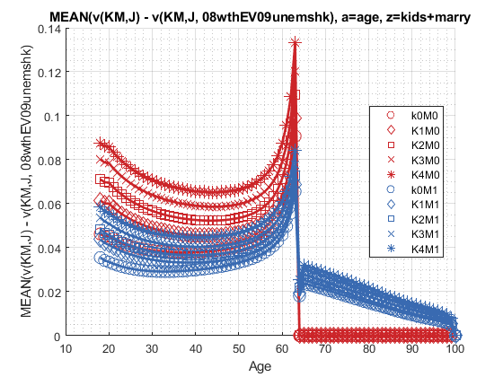

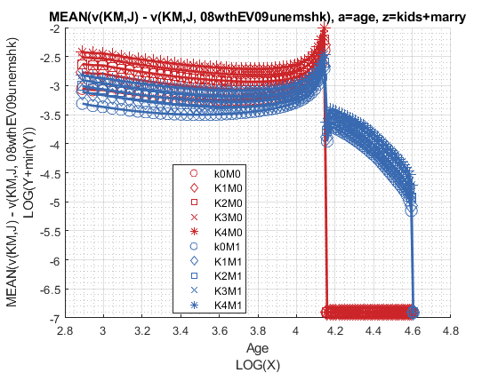

```matlab
mp_support_graph('cl_st_graph_title') = {'MEAN(v(KM,J) - v(KM,J, 08wthEV09unemshk), a=age, z=kids+marry'};
mp_support_graph('cl_st_ytitle') = {'MEAN(v(KM,J) - v(KM,J, 08wthEV09unemshk)'};
ff_graph_grid((tb_az_v{1:end, 4:end}), ar_row_grid, age_grid, mp_support_graph);
```

Graph Mean Savings Choices Change:

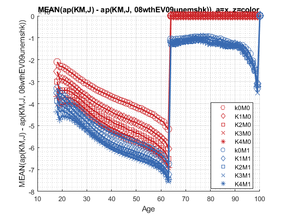

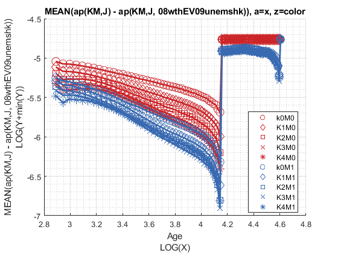

```matlab
mp_support_graph('cl_st_graph_title') = {'MEAN(ap(KM,J) - ap(KM,J, 08wthEV09unemshk)), a=x, z=color'};
mp_support_graph('cl_st_ytitle') = {'MEAN(ap(KM,J) - ap(KM,J, 08wthEV09unemshk))'};
ff_graph_grid((tb_az_ap{1:end, 4:end}), ar_row_grid, age_grid, mp_support_graph);
```

Graph Mean Consumption Change:

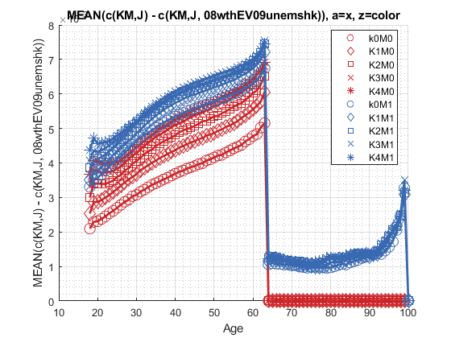

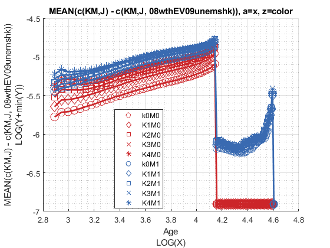

```matlab
mp_support_graph('cl_st_graph_title') = {'MEAN(c(KM,J) - c(KM,J, 08wthEV09unemshk)), a=x, z=color'};
mp_support_graph('cl_st_ytitle') = {'MEAN(c(KM,J) - c(KM,J, 08wthEV09unemshk))'};
ff_graph_grid((tb_az_c{1:end, 4:end}), ar_row_grid, age_grid, mp_support_graph);
```

## Analyze Education and Marriage and Age

```matlab
% Generate some Data
mp_support_graph = containers.Map('KeyType', 'char', 'ValueType', 'any');
ar_row_grid = ["E0M0", "E1M0", "E0M1", "E1M1"];
mp_support_graph('cl_st_xtitle') = {'Age'};
mp_support_graph('st_legend_loc') = 'best';
mp_support_graph('bl_graph_logy') = true; % do not log
mp_support_graph('st_rounding') = '6.2f'; % format shock legend
mp_support_graph('cl_scatter_shapes') = {'*', 'p', '*','p' };
mp_support_graph('cl_colors') = {'red', 'red', 'blue', 'blue'};
```

MEAN(v(EKM,J) - v(EKM,J, 08wthEV09unemshk)), MEAN(ap(EM,J, steady) - ap(EM,J, 08wthEV09unemshk)), MEAN(c(EM,J, steady) - c(EM,J, 08wthEV09unemshk))

Tabulate value and policies:

```matlab
% Set
% NaN(n_jgrid,n_agrid,n_etagrid,n_educgrid,n_marriedgrid,n_kidsgrid);
ar_permute = [2,3,6,1,4,5];
% Value Function
tb_az_v = ff_summ_nd_array("MEAN(v(EM,J, steady) - v(EM,J, 08wthEV09unemshk))", V_VFI_unemp_drop, true, ["mean"], 3, 1, cl_mp_datasetdesc, ar_permute);
```

xxx MEAN(v(EM,J, steady) - v(EM,J, 08wthEV09unemshk)) xxxxxxxxxxxxxxxxxxxxxxxxxxx **group** **edu** **marry** **mean_age_18** **mean_age_19** **mean_age_20** **mean_age_21** **mean_age_22** **mean_age_23** **mean_age_24** **mean_age_25** **mean_age_26** **mean_age_27** **mean_age_28** **mean_age_29** **mean_age_30** **mean_age_31** **mean_age_32** **mean_age_33** **mean_age_34** **mean_age_35** **mean_age_36** **mean_age_37** **mean_age_38** **mean_age_39** **mean_age_40** **mean_age_41** **mean_age_42** **mean_age_43** **mean_age_44** **mean_age_45** **mean_age_46** **mean_age_47** **mean_age_48** **mean_age_49** **mean_age_50** **mean_age_51** **mean_age_52** **mean_age_53** **mean_age_54** **mean_age_55** **mean_age_56** **mean_age_57** **mean_age_58** **mean_age_59** **mean_age_60** **mean_age_61** **mean_age_62** **mean_age_63** **mean_age_64** **mean_age_65** **mean_age_66** **mean_age_67** **mean_age_68** **mean_age_69** **mean_age_70** **mean_age_71** **mean_age_72** **mean_age_73** **mean_age_74** **mean_age_75** **mean_age_76** **mean_age_77** **mean_age_78** **mean_age_79** **mean_age_80** **mean_age_81** **mean_age_82** **mean_age_83** **mean_age_84** **mean_age_85** **mean_age_86** **mean_age_87** **mean_age_88** **mean_age_89** **mean_age_90** **mean_age_91** **mean_age_92** **mean_age_93** **mean_age_94** **mean_age_95** **mean_age_96** **mean_age_97** **mean_age_98** **mean_age_99** **mean_age_100** **_____** **___** **_____** **___________** **___________** **___________** **___________** **___________** **___________** **___________** **___________** **___________** **___________** **___________** **___________** **___________** **___________** **___________** **___________** **___________** **___________** **___________** **___________** **___________** **___________** **___________** **___________** **___________** **___________** **___________** **___________** **___________** **___________** **___________** **___________** **___________** **___________** **___________** **___________** **___________** **___________** **___________** **___________** **___________** **___________** **___________** **___________** **___________** **___________** **___________** **___________** **___________** **___________** **___________** **___________** **___________** **___________** **___________** **___________** **___________** **___________** **___________** **___________** **___________** **___________** **___________** **___________** **___________** **___________** **___________** **___________** **___________** **___________** **___________** **___________** **___________** **___________** **___________** **___________** **___________** **___________** **___________** **___________** **___________** **___________** **____________** 1 0 0 0.084881 0.083361 0.083388 0.08165 0.080055 0.078588 0.077239 0.075997 0.074853 0.0738 0.07283 0.07194 0.071124 0.070378 0.069698 0.069081 0.068524 0.068026 0.067584 0.067197 0.066864 0.066585 0.066…

```matlab
% Aprime Choice
tb_az_ap = ff_summ_nd_array("MEAN(ap(EM,J, steady) - ap(EM,J, 08wthEV09unemshk))", ap_VFI_unemp_drop, true, ["mean"], 3, 1, cl_mp_datasetdesc, ar_permute);
```

xxx MEAN(ap(EM,J, steady) - ap(EM,J, 08wthEV09unemshk)) xxxxxxxxxxxxxxxxxxxxxxxxxxx **group** **edu** **marry** **mean_age_18** **mean_age_19** **mean_age_20** **mean_age_21** **mean_age_22** **mean_age_23** **mean_age_24** **mean_age_25** **mean_age_26** **mean_age_27** **mean_age_28** **mean_age_29** **mean_age_30** **mean_age_31** **mean_age_32** **mean_age_33** **mean_age_34** **mean_age_35** **mean_age_36** **mean_age_37** **mean_age_38** **mean_age_39** **mean_age_40** **mean_age_41** **mean_age_42** **mean_age_43** **mean_age_44** **mean_age_45** **mean_age_46** **mean_age_47** **mean_age_48** **mean_age_49** **mean_age_50** **mean_age_51** **mean_age_52** **mean_age_53** **mean_age_54** **mean_age_55** **mean_age_56** **mean_age_57** **mean_age_58** **mean_age_59** **mean_age_60** **mean_age_61** **mean_age_62** **mean_age_63** **mean_age_64** **mean_age_65** **mean_age_66** **mean_age_67** **mean_age_68** **mean_age_69** **mean_age_70** **mean_age_71** **mean_age_72** **mean_age_73** **mean_age_74** **mean_age_75** **mean_age_76** **mean_age_77** **mean_age_78** **mean_age_79** **mean_age_80** **mean_age_81** **mean_age_82** **mean_age_83** **mean_age_84** **mean_age_85** **mean_age_86** **mean_age_87** **mean_age_88** **mean_age_89** **mean_age_90** **mean_age_91** **mean_age_92** **mean_age_93** **mean_age_94** **mean_age_95** **mean_age_96** **mean_age_97** **mean_age_98** **mean_age_99** **mean_age_100** **_____** **___** **_____** **___________** **___________** **___________** **___________** **___________** **___________** **___________** **___________** **___________** **___________** **___________** **___________** **___________** **___________** **___________** **___________** **___________** **___________** **___________** **___________** **___________** **___________** **___________** **___________** **___________** **___________** **___________** **___________** **___________** **___________** **___________** **___________** **___________** **___________** **___________** **___________** **___________** **___________** **___________** **___________** **___________** **___________** **___________** **___________** **___________** **___________** **___________** **___________** **___________** **___________** **___________** **___________** **___________** **___________** **___________** **___________** **___________** **___________** **___________** **___________** **___________** **___________** **___________** **___________** **___________** **___________** **___________** **___________** **___________** **___________** **___________** **___________** **___________** **___________** **___________** **___________** **___________** **___________** **___________** **___________** **___________** **___________** **____________** 1 0 0 -0.0028826 -0.003052 -0.0031902 -0.0032817 -0.0033667 -0.0034573 -0.0035364 -0.003631 -0.0037067 -0.0038108 -0.0038855 -0.0039779 -0.0040428 -0.004133 -0.0042158 -0.0042941 -0.0043594 -0.0044363 -…

```matlab
% Consumption Choices
tb_az_c = ff_summ_nd_array("MEAN(c(EM,J, steady) - c(EM,J, 08wthEV09unemshk))", cons_VFI_unemp_drop, true, ["mean"], 3, 1, cl_mp_datasetdesc, ar_permute);
```

xxx MEAN(c(EM,J, steady) - c(EM,J, 08wthEV09unemshk)) xxxxxxxxxxxxxxxxxxxxxxxxxxx **group** **edu** **marry** **mean_age_18** **mean_age_19** **mean_age_20** **mean_age_21** **mean_age_22** **mean_age_23** **mean_age_24** **mean_age_25** **mean_age_26** **mean_age_27** **mean_age_28** **mean_age_29** **mean_age_30** **mean_age_31** **mean_age_32** **mean_age_33** **mean_age_34** **mean_age_35** **mean_age_36** **mean_age_37** **mean_age_38** **mean_age_39** **mean_age_40** **mean_age_41** **mean_age_42** **mean_age_43** **mean_age_44** **mean_age_45** **mean_age_46** **mean_age_47** **mean_age_48** **mean_age_49** **mean_age_50** **mean_age_51** **mean_age_52** **mean_age_53** **mean_age_54** **mean_age_55** **mean_age_56** **mean_age_57** **mean_age_58** **mean_age_59** **mean_age_60** **mean_age_61** **mean_age_62** **mean_age_63** **mean_age_64** **mean_age_65** **mean_age_66** **mean_age_67** **mean_age_68** **mean_age_69** **mean_age_70** **mean_age_71** **mean_age_72** **mean_age_73** **mean_age_74** **mean_age_75** **mean_age_76** **mean_age_77** **mean_age_78** **mean_age_79** **mean_age_80** **mean_age_81** **mean_age_82** **mean_age_83** **mean_age_84** **mean_age_85** **mean_age_86** **mean_age_87** **mean_age_88** **mean_age_89** **mean_age_90** **mean_age_91** **mean_age_92** **mean_age_93** **mean_age_94** **mean_age_95** **mean_age_96** **mean_age_97** **mean_age_98** **mean_age_99** **mean_age_100** **_____** **___** **_____** **___________** **___________** **___________** **___________** **___________** **___________** **___________** **___________** **___________** **___________** **___________** **___________** **___________** **___________** **___________** **___________** **___________** **___________** **___________** **___________** **___________** **___________** **___________** **___________** **___________** **___________** **___________** **___________** **___________** **___________** **___________** **___________** **___________** **___________** **___________** **___________** **___________** **___________** **___________** **___________** **___________** **___________** **___________** **___________** **___________** **___________** **___________** **___________** **___________** **___________** **___________** **___________** **___________** **___________** **___________** **___________** **___________** **___________** **___________** **___________** **___________** **___________** **___________** **___________** **___________** **___________** **___________** **___________** **___________** **___________** **___________** **___________** **___________** **___________** **___________** **___________** **___________** **___________** **___________** **___________** **___________** **___________** **____________** 1 0 0 0.0028826 0.003052 0.0031902 0.0032817 0.0033667 0.0034573 0.0035364 0.003631 0.0037067 0.0038108 0.0038855 0.0039779 0.0040428 0.004133 0.0042158 0.0042941 0.0043594 0.0044363 0.0045136 0.0045695 0…

Graph Mean Values Change:

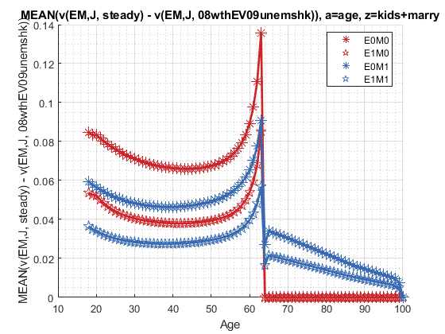

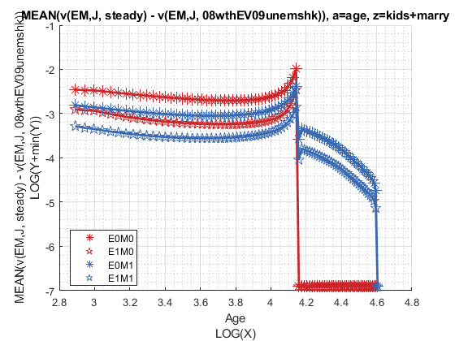

```matlab
mp_support_graph('cl_st_graph_title') = {'MEAN(v(EM,J, steady) - v(EM,J, 08wthEV09unemshk)), a=age, z=kids+marry'};
mp_support_graph('cl_st_ytitle') = {'MEAN(v(EM,J, steady) - v(EM,J, 08wthEV09unemshk))'};
ff_graph_grid((tb_az_v{1:end, 4:end}), ar_row_grid, age_grid, mp_support_graph);
```

Graph Mean Savings Choices Change:

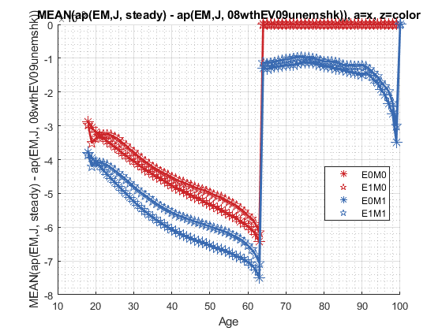

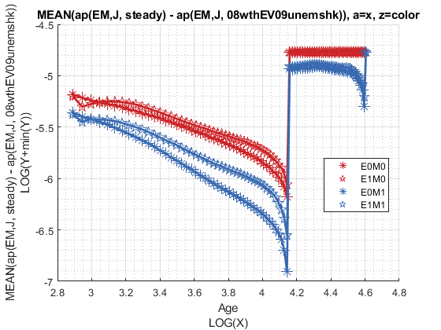

```matlab
mp_support_graph('cl_st_graph_title') = {'MEAN(ap(EM,J, steady) - ap(EM,J, 08wthEV09unemshk)), a=x, z=color'};
mp_support_graph('cl_st_ytitle') = {'MEAN(ap(EM,J, steady) - ap(EM,J, 08wthEV09unemshk))'};
ff_graph_grid((tb_az_ap{1:end, 4:end}), ar_row_grid, age_grid, mp_support_graph);
```

Graph Mean Consumption Change:

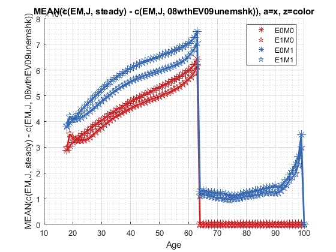

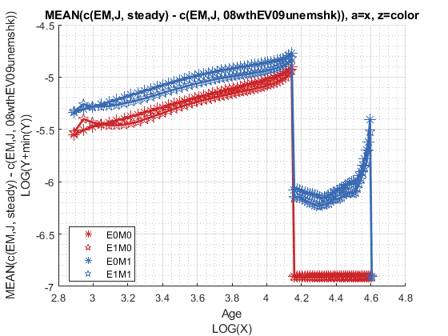

```matlab
mp_support_graph('cl_st_graph_title') = {'MEAN(c(EM,J, steady) - c(EM,J, 08wthEV09unemshk)), a=x, z=color'};
mp_support_graph('cl_st_ytitle') = {'MEAN(c(EM,J, steady) - c(EM,J, 08wthEV09unemshk))'};
ff_graph_grid((tb_az_c{1:end, 4:end}), ar_row_grid, age_grid, mp_support_graph);
```